# Activity 15 - Chi-Squared Tests (Solutions)

STS 2300

Updated: 2025-05-03

Below are the packages you will need for this activity. If you use other packages, you can add them here.

```r
library(ggplot2)
library(infer)
library(dplyr)
```

# TV Viewing Habits

An [online survey](https://today.yougov.com/entertainment/articles/42297-tv-and-streaming-yougov-poll-april-21-25-2022) explored people’s TV viewing habits and gathered some demographic information. There were four age categories that people could choose from. They were also asked how often they binge watch shows. The code below reads the data into R and will be used beginning in Step 2.

```r
tv <- data.frame(age = c(rep("under 30", 183), rep("30 - 44", 220),
                         rep("45 - 64", 313), rep("65+", 213)),
                 binge_tv = c(rep("always", 17), rep("most of the time", 53),
                              rep("half the time", 41), rep("sometimes", 59),
                              rep("never", 13),
                              rep("always", 31), rep("most of the time", 46),
                              rep("half the time", 36), rep("sometimes", 76),
                              rep("never", 31),
                              rep("always", 12), rep("most of the time", 41),
                              rep("half the time", 60), rep("sometimes", 161),
                              rep("never", 39),
                              rep("always", 6), rep("most of the time", 15),
                              rep("half the time", 28), rep("sometimes", 121),
                              rep("never", 43)))
```

1. Step 1 - Suppose we wanted to know something about how TV viewing habits related to age. What would the hypotheses be for a Chi-squared test based on this information?

$H_0$: There is *no relationship* between age and how often someone binge watches TV shows.

$H_a$: There is *some sort of relationship* between age and how often someone binge watches TV shows.

2. Step 2 - The code at the top reads the data from the survey into R. Create a graph displaying the data in relation to our question of interest. What do you notice in the graph?

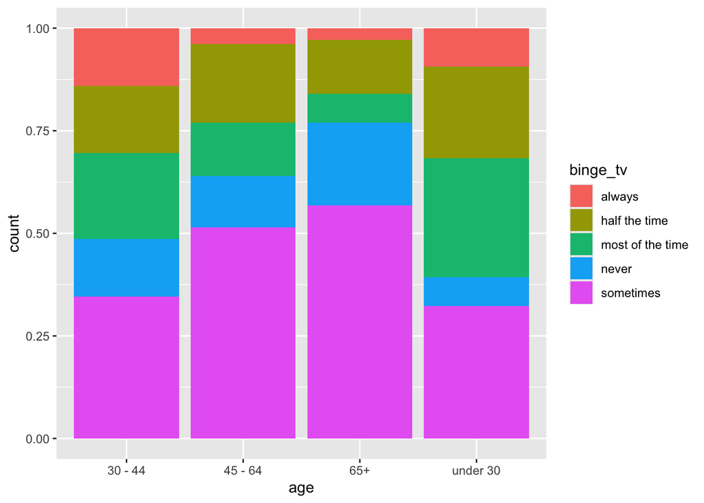

```r
ggplot(tv, aes(x = age, fill = binge_tv)) +
  geom_bar(position = "fill")
```

**Answer:** There do seem to be differences in the groups. For example, 65+ year olds are much more likely to say they binge watch TV shows sometimes than people under 30.

3. Step 2 continued - Calculate a chi-squared statistic for this question.

```r
tv_stat <- tv |>
  specify(age ~ binge_tv) |>
  calculate(stat = "chisq")
tv_stat
```

```
## Response: age (factor)
## Explanatory: binge_tv (factor)
## # A tibble: 1 × 1
##    stat
##   <dbl>
## 1  99.4
```

**Statistic:** $\chi^2 = 99.45$

4. Step 3 - Create a null distribution and visualize it with a p-value shaded in. Then calculate the p-value and write a sentence about what the p-value means in context of this example.

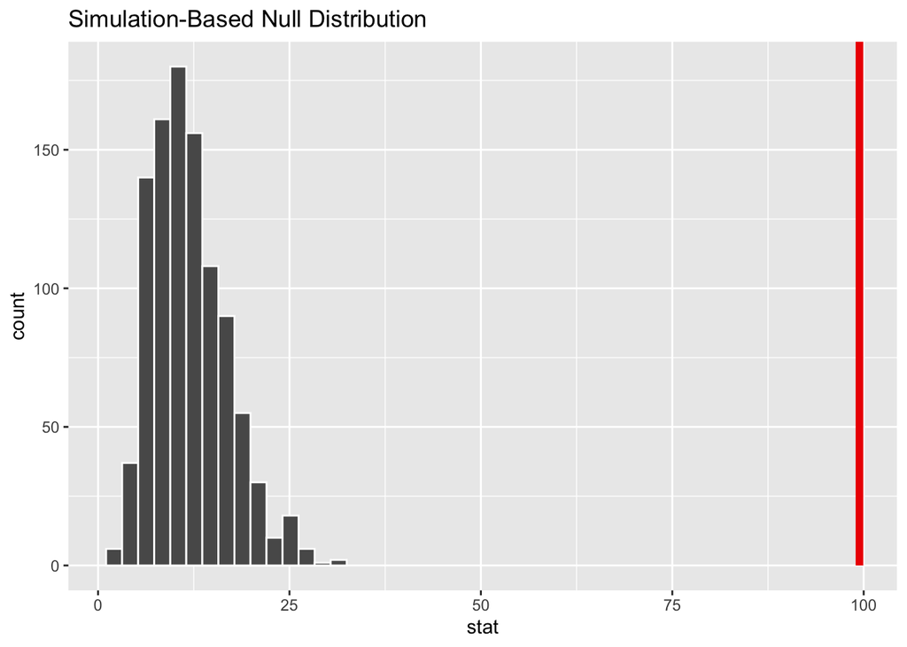

```r
set.seed(10316)
tv_null <- tv |>
  specify(age ~ binge_tv) |>
  hypothesize(null = "independence") |>
  generate(reps = 1000, type = "permute") |>
  calculate(stat = "chisq")

visualize(tv_null) +
  shade_pvalue(obs_stat = tv_stat,
               direction = "right")
```

```r
tv_null |>
  get_pvalue(obs_stat = tv_stat,
             direction = "right")
```

```
## # A tibble: 1 × 1
##   p_value
##     <dbl>
## 1       0
```

**p-value =** approximately 0

**Sentence:** In a world where there is no relationship between age and binge watching habits, we would almost never see data with a chi-squared statistic as high as 99.45.

5. Step 4 - Write a formal conclusion for this example.

**Conclusion:** With a p-value of approximately 0, we reject the null hypothesis. There is very strong evidence of some sort of relationship between how often people binge watch TV and their age.

6. How can we know which direction to shade for the p-value in this (or any) chi-squared example?

**Answer:** We shade in the direction that favors the alternative hypothesis. When the alternative hypothesis is true, the chi-squared statistic will get larger because what we observe will not look like what we expect when the null is true.